# Looking at Traits

Going to look at some patterns in traits

```r
library(ggplot2)
library(data.table)
library(lme4)
library(MuMIn)
traits <- read.csv("TraitCollectionFishNAtlanticNEPacificContShelf (3).csv")
traits <- data.table(traits)
#remove duplicates
traits.u <- unique(traits, by = c('taxon'))
```

Interested in looking at max age, trophic level, and age of maturity

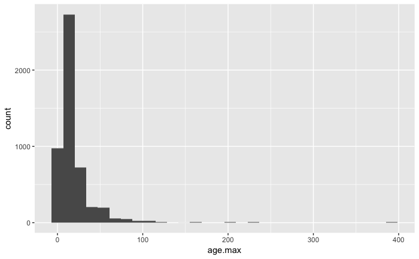

```r
ggplot(aes(x=age.max), data = traits) +
  geom_histogram()
```

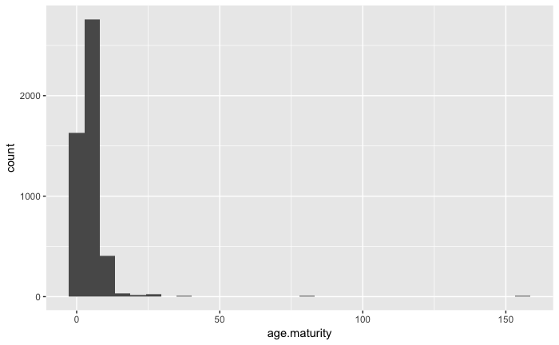

```r
ggplot(aes(x=age.maturity), data = traits) +
  geom_histogram()
```

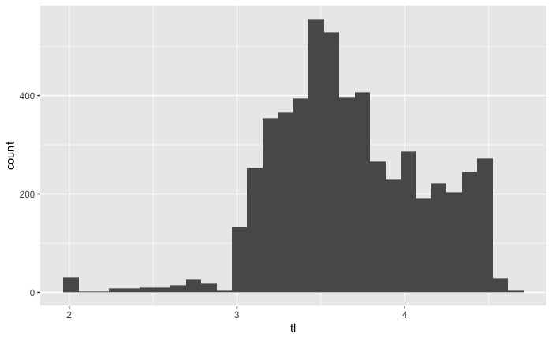

```r
ggplot(aes(x=tl), data = traits) +
  geom_histogram()
```

```r
cor(na.omit(traits[,c(10, 17, 22)]))
```

```
                    tl age.maturity   age.max
tl           1.0000000    0.1749154 0.2154123
age.maturity 0.1749154    1.0000000 0.7285740
age.max      0.2154123    0.7285740 1.0000000
```

They have a R^2 value of 0.53, so, worth it to try both.

Let’s link species

First, let’s see if there are any errors?

```r
load("spp_master_ztemp.Rdata")
spp_master_spp <- data.frame(spp = unique(spp_master_ztemp$spp), origin = "spp_master")
traits_spp <- data.frame(spp = unique(traits$taxon), origin = "traits")
spp_all <- rbind(spp_master_spp, traits_spp)
spp_all$spp <- as.character(spp_all$spp)
spp_all.u <- spp_all[!duplicated(spp_all$spp),]
```

# Species to fix

species | location

Arctozenus risso | spp_master Arctozenus risso kroyeri | spp_master *Arctozenus risso in traits, so best to apply same to both Arctozenus and Artozenus risso kroyeri in spp_master

```r
row <- traits.u[taxon == "Arctozenus risso",]
row[,taxon := "Arctozenus risso kroyeri"][, species := "risso kroyeri"]
traits.u <- rbind(traits.u, row)
```

Myoxocephalus scorpioides | spp_master Myoxocephalus scorpius | spp_master *yes, these are different!

Auxis rochei rochei | traits *ignore, not in our hauls

Diplecogaster bimaculata | traits Diplecogaster bimaculata bimaculata | traits *ignore, not in our hauls

Etrumeus teres | traits Etrumeus teres(sadina) | spp_master *change spp_master to Etrumeus teres

```r
spp_master_ztemp[spp == "Etrumeus teres(sadina)", spp := "Etrumeus teres"]
```

Eualus gaimardii gaimardii | spp_master *ignore, not in trait database

Gasterosteus aculeatus | traits Gasterosteus aculeatus williamsoni | traits *ignore, not in our hauls

Lestidiops jayakari | traits Lestidiops jayakari jayakari | traits *ignore, not in our hauls

Liparis liparis liparis | traits *ignore, not in our hauls

Macroramphosus scolopax | traits Macrorhamphosus scolopax | spp_master *spelling error in spp_master, change to Macroramphosus scolopax

```r
spp_master_ztemp[spp == "Macrorhamphosus scolopax", spp := "Macroramphosus scolopax"]
```

Mullus barbatus barbatus | traits *ignore, not in our hauls

Myliobatis freminvillei | traits Myliobatis freminvillii | spp_master *spelling error in spp_master, change to Myliobatis freminvillei

```r
spp_master_ztemp[spp == "Myliobatis freminvillii", spp := "Myliobatis freminvillei"]
```

Nicholsina usta usta | traits *ignore, not in our hauls

Notoscopelus elongatus kroyeri | traits *ignore, not in our hauls

Oxyporhamphus micropterus micropterus | traits *ignore, not in our hauls

Polydactylus octoemus | spp_master Polydactylus octonemus | traits *spelling error in spp_master, change to Polydactylus octonemus

```r
spp_master_ztemp[spp == "Polydactylus octoemus", spp := "Polydactylus octonemus"]
```

Salmo trutta trutta | traits *ignore, not in our hauls

Scomberesox saurus saurus | traits *ignore, not in our hauls

Stichaeus punctatus | spp_master Stichaeus punctatus punctatus | traits *delte one punctatus from traits

```r
traits.u[taxon == "Stichaeus punctatus punctatus", taxon := "Stichaeus punctatus"][species == "punctatus punctatus", species := "punctatus"]
```

Stomias boa boa | traits Stomias boa ferox | traits *ignore, not in our trawls

Symphurus civitatium | traits Symphurus civitatum | spp_master *spelling error in spp_master, change to Symphurus civitatium

```r
spp_master_ztemp[spp == "Symphurus civitatum", spp := "Symphurus civitatium"]
```

Zenopsis conchifer | traits Zenopsis conchifera | spp_master *spelling error in spp_master, change to Zenopsis conchifer

```r
spp_master_ztemp[spp == "Zenopsis conchifera", spp := "Zenopsis conchifer"]
```

Okay, now we can go forward. Let’s link traits to spp_master with temp data

```r
traits.u[, spp := taxon][, taxon := NULL]
spp_master_ztemp.traits <- spp_master_ztemp[traits.u, nomatch = 0, on = c("spp")]
```

Now to save updated data.table with traits for species we have traits for

```r
save(spp_master_ztemp.traits, file = "spp_master_ztemp.traits.Rdata")
```

# Now, what happens if we add traits to our models?

Let’s just look at our best models

Best colonization models without traits:

| variable | coefficient | p | AICc |
| --- | --- | --- | --- |
| 1 | max_sbt_temp_change_abs | 0.23859896 | 4.768169e-06 |
| 2 | max_sst_temp_change_abs_lag1 | -0.23972849 | 7.626257e-04 |
| 3 | min_sbt_temp_change_abs_lag5 | -0.24444356 | 2.224470e-03 |
| 4 | max_sbt_temp_change_abs_lag3 | 0.17106664 | 1.235113e-03 |
| 5 | seas_sbt_temp_change_abs | 0.14237610 | 1.832988e-03 |
| 6 | max_sst_temp_change_abs_lag8 | 0.19094887 | 2.065176e-03 |
| 7 | seas_sst_temp_change_abs_lag8 | 0.12714037 | 3.919052e-03 |
| 8 | seas_sbt_temp_change_abs_lag4 | 0.13592310 | 5.378231e-03 |
| 9 | max_sbt_temp_change_lag8 | -0.11479683 | 6.230307e-03 |
| 10 | seas_sbt_temp_change_abs_lag1 | 0.12614156 | 7.121969e-03 |
| 11 | max_sbt_temp_change_abs_lag1 | 0.13913884 | 9.612377e-03 |
| 12 | seas_sst_temp_change_abs | 0.10400362 | 1.380557e-02 |
| 13 | max_sst_temp_change_abs_lag3 | 0.15225482 | 1.668734e-02 |
| 14 | max_sst_temp_change_abs | 0.16851906 | 2.258119e-02 |
| 15 | min_sst_temp_change_lag5 | 0.07967662 | 2.537698e-02 |

Now, I need to run all models again with this restricted data set. Do the models hold up? Then, I will see how adding traits changes things.

## Maximum age and colonization

```r
spp_master_ztemp.traits.na.age.max <- na.omit(spp_master_ztemp.traits, cols="age.max")
```

[output not shown]

Do top models hold up? This is telling me that previous best model (max sbt temp change abs) is still good, but not the best… Malin says it’s okay, as long as similar models are coming out on top. 11/15 top models shared.

| variable | coefficient | p | AICc | rank above | coef above |
| --- | --- | --- | --- | --- | --- |
| 1 | seas_sst_temp_change_abs | 0.16747228 | 0.001059902 | 4239.108 | 12 |
| 2 | max_sbt_temp_change_abs_lag3 | 0.19569357 | 0.001885719 | 4239.951 | 4 |
| 3 | max_sst_temp_change_abs_lag1 | -0.26280961 | 0.003919178 | 4240.645 | 2 |
| 4 | max_sbt_temp_change_abs | 0.16256132 | 0.009148480 | 4242.650 | 1 |
| 5 | max_sbt_temp_change_abs_lag1 | 0.16616085 | 0.010718533 | 4242.893 | 11 |
| 6 | seas_sbt_temp_change_abs | 0.13226661 | 0.016386407 | 4243.561 | 5 |
| 7 | seas_sbt_temp_change_abs_lag4 | 0.14075757 | 0.019188279 | 4243.750 | 8 |
| 8 | max_sst_temp_change_abs_lag6 | -0.20512821 | 0.024157883 | 4243.823 | not in top 15 |
| 9 | seas_sbt_temp_change_abs_lag1 | 0.12951678 | 0.026914136 | 4244.384 | 9 |
| 10 | max_sst_temp_change_abs_lag8 | 0.17240059 | 0.028828987 | 4244.709 | 6 |
| 11 | seas_sst_temp_change_abs_lag6 | -0.12608343 | 0.043620010 | 4244.899 | not in top 15 |
| 12 | max_sst_temp_change_abs | 0.19930194 | 0.042940256 | 4245.196 | 14 |
| 13 | seas_sst_temp_change_lag5 | -0.07459168 | 0.049345998 | 4245.232 | not in top 15 |
| 14 | seas_sbt_temp_lag10 | 0.08104661 | 0.048357908 | 4245.336 | not in top 15 |
| 15 | min_sbt_temp_change_abs_lag5 | -0.18602894 | 0.060853920 | 4245.388 | 3 |

Now we will check to see if including max age improves best models.

```r
#new base model (best model with no traits added)
mod.c.agemax.0 <- glmer(col ~ max_sbt_temp_change_abs + (1|reg) + (1|year_factor), family = binomial, data = spp_master_ztemp.traits.na.age.max)
summary(mod.c.agemax.0)
AICc(mod.c.agemax.0)

#max_sbt_temp_change_abs          0.16256   0.00915 4242.65
```

```r
#max_sbt_temp_change_abs and age.max
mod.c.agemax.1 <- glmer(col ~ max_sbt_temp_change_abs + age.max + (1|reg) + (1|year_factor), family = binomial, data = spp_master_ztemp.traits.na.age.max)
summary(mod.c.agemax.1)
AICc(mod.c.agemax.1)


  #max_sbt_temp_change_abs and             0.155462 0.0127  4204.059
      #                       age.max      -0.025250 1.42e-08
```

```r
mod.c.agemax.2 <- glmer(col ~ max_sbt_temp_change_abs * age.max + (1|reg) + (1|year_factor), family = binomial, data = spp_master_ztemp.traits.na.age.max)
summary(mod.c.agemax.2)
```

```
Generalized linear mixed model fit by maximum likelihood (Laplace Approximation) ['glmerMod']
 Family: binomial  ( logit )
Formula: col ~ max_sbt_temp_change_abs * age.max + (1 | reg) + (1 | year_factor)
   Data: spp_master_ztemp.traits.na.age.max

     AIC      BIC   logLik deviance df.resid
  4203.4   4248.0  -2095.7   4191.4    12588

Scaled residuals:
    Min      1Q  Median      3Q     Max
 -0.437  -0.230  -0.177  -0.147 155.246

Random effects:
 Groups      Name        Variance Std.Dev.
 year_factor (Intercept) 0.08664  0.2944
 reg         (Intercept) 0.22720  0.4767
Number of obs: 12594, groups:  year_factor, 45; reg, 9

Fixed effects:
                                 Estimate Std. Error z value Pr(>|z|)
(Intercept)                     -3.172823   0.204258 -15.533  < 2e-16 ***
max_sbt_temp_change_abs          0.055470   0.088216   0.629   0.5295
age.max                         -0.031236   0.005892  -5.301 1.15e-07 ***
max_sbt_temp_change_abs:age.max  0.008543   0.005074   1.684   0.0922 .
---
Signif. codes:  0 ‘***’ 0.001 ‘**’ 0.01 ‘*’ 0.05 ‘.’ 0.1 ‘ ’ 1

Correlation of Fixed Effects:
            (Intr) mx____ age.mx
mx_sbt_tm__ -0.342
age.max     -0.395  0.442
mx_sbt___:.  0.251 -0.709 -0.643
```

```r
AICc(mod.c.agemax.2)
```

```
[1] 4203.399
```

```r
#what about only max age?
mod.c.agemax.3 <- glmer(col ~ age.max + (1|reg) + (1|year_factor), family = binomial, data = spp_master_ztemp.traits.na.age.max)
summary(mod.c.agemax.3)
AICc(mod.c.agemax.3)

  #4208.04
```

Comparing above options (no trait, yes trait, yes trait with interaction, only trait)

```r
AICc(mod.c.agemax.0, mod.c.agemax.1, mod.c.agemax.2, mod.c.agemax.3)
```

[output not shown]

Can we make a plot for how likelihood of colonization and extinction changes with age.max?

```r
ggplot(aes(x=age.max), data = spp_master_ztemp.traits.na.age.max) +
  geom_histogram() +
  facet_wrap(~reg)

#appears to be similar across regions? just many more in neus
```

[output not shown]

## Age of Maturity for Colonization

Do top models hold up? This is telling me that previous best model (max sbt temp change abs) is still good, but not the best… Malin says it’s okay, as long as similar models are coming out on top

| variable | coefficient | p | AICc | rank above | coef above |
| --- | --- | --- | --- | --- | --- |
| 1 | seas_sst_temp_change_abs | 0.16732168 | 0.001055896 | 4237.134 | 12 |
| 2 | max_sst_temp_change_abs_lag1 | -0.26275332 | 0.004143103 | 4238.738 | 2 |
| 3 | max_sbt_temp_change_abs_lag3 | 0.18628409 | 0.003083958 | 4238.804 | 4 |
| 4 | max_sst_temp_change_abs_lag6 | -0.22361557 | 0.014782142 | 4240.889 | not in top 15 |
| 5 | max_sbt_temp_change_abs | 0.15801135 | 0.011635865 | 4241.039 | 1 |
| 6 | max_sst_temp_change_abs_lag8 | 0.19598072 | 0.012668985 | 4241.366 | 6 |
| 7 | max_sbt_temp_change_abs_lag1 | 0.15825795 | 0.014922452 | 4241.440 | 11 |
| 9 | seas_sbt_temp_change_abs | 0.13079589 | 0.017830284 | 4241.690 | 5 |
| 10 | seas_sbt_temp_change_abs_lag4 | 0.13424702 | 0.024563505 | 4242.176 | 8 |
| 11 | seas_sst_temp_change_abs_lag6 | -0.13386926 | 0.033532762 | 4242.414 | not in top 15 |
| 12 | seas_sbt_temp_change_abs_lag1 | 0.12498712 | 0.031649631 | 4242.646 | 10 |
| 13 | min_sbt_temp_change_abs_lag5 | -0.19180573 | 0.054000799 | 4243.150 | 3 |
| 14 | seas_sst_temp_change_lag5 | -0.07497315 | 0.049187743 | 4243.216 | not in top 15 |
| 15 | seas_sbt_temp_lag10 | 0.07724898 | 0.059318089 | 4243.639 | not in top 15 |

In top 15, 11/15 shared.

Now we will check to see if including age at maturity improves best models.

```r
#new base model (best model with no traits added)
mod.c.agematurity.0 <- glmer(col ~ max_sbt_temp_change_abs + (1|reg) + (1|year_factor), family = binomial, data = spp_master_ztemp.traits.na.age.maturity)
summary(mod.c.agematurity.0)
```

```
Generalized linear mixed model fit by maximum likelihood (Laplace Approximation) ['glmerMod']
 Family: binomial  ( logit )
Formula: col ~ max_sbt_temp_change_abs + (1 | reg) + (1 | year_factor)
   Data: spp_master_ztemp.traits.na.age.maturity

     AIC      BIC   logLik deviance df.resid
  4241.0   4270.8  -2116.5   4233.0    12741

Scaled residuals:
    Min      1Q  Median      3Q     Max
-0.3775 -0.2342 -0.1766 -0.1471  8.7158

Random effects:
 Groups      Name        Variance Std.Dev.
 year_factor (Intercept) 0.09367  0.3061
 reg         (Intercept) 0.23161  0.4813
Number of obs: 12745, groups:  year_factor, 45; reg, 9

Fixed effects:
                        Estimate Std. Error z value Pr(>|z|)
(Intercept)             -3.68011    0.18940 -19.430   <2e-16 ***
max_sbt_temp_change_abs  0.15801    0.06263   2.523   0.0116 *
---
Signif. codes:  0 ‘***’ 0.001 ‘**’ 0.01 ‘*’ 0.05 ‘.’ 0.1 ‘ ’ 1

Correlation of Fixed Effects:
            (Intr)
mx_sbt_tm__ -0.256
```

```r
AICc(mod.c.agematurity.0)
```

```
[1] 4241.039
```

```r
  #max_sbt_temp_change_abs  0.15801  0.0116 4241.039
```

```r
mod.c.agematurity.1 <- glmer(col ~ max_sbt_temp_change_abs + age.maturity + (1|reg) + (1|year_factor), family = binomial, data = spp_master_ztemp.traits.na.age.maturity)
summary(mod.c.agematurity.1)
```

```
Generalized linear mixed model fit by maximum likelihood (Laplace Approximation) ['glmerMod']
 Family: binomial  ( logit )
Formula: col ~ max_sbt_temp_change_abs + age.maturity + (1 | reg) + (1 |      year_factor)
   Data: spp_master_ztemp.traits.na.age.maturity

     AIC      BIC   logLik deviance df.resid
  4236.7   4274.0  -2113.4   4226.7    12740

Scaled residuals:
    Min      1Q  Median      3Q     Max
-0.4023 -0.2335 -0.1754 -0.1470 29.0997

Random effects:
 Groups      Name        Variance Std.Dev.
 year_factor (Intercept) 0.09383  0.3063
 reg         (Intercept) 0.22650  0.4759
Number of obs: 12745, groups:  year_factor, 45; reg, 9

Fixed effects:
                        Estimate Std. Error z value Pr(>|z|)
(Intercept)             -3.51952    0.19879 -17.705   <2e-16 ***
max_sbt_temp_change_abs  0.15503    0.06257   2.478   0.0132 *
age.maturity            -0.03818    0.01601  -2.384   0.0171 *
---
Signif. codes:  0 ‘***’ 0.001 ‘**’ 0.01 ‘*’ 0.05 ‘.’ 0.1 ‘ ’ 1

Correlation of Fixed Effects:
            (Intr) mx____
mx_sbt_tm__ -0.252
age.maturty -0.325  0.019
```

```r
AICc(mod.c.agematurity.1)
```

```
[1] 4236.753
```

```r
#max_sbt_temp_change_abs  0.15503   0.0132 4236.753
#age.maturity            -0.03818   0.0171
```

```r
mod.c.agematurity.2 <- glmer(col ~ max_sbt_temp_change_abs * age.maturity + (1|reg) + (1|year_factor), family = binomial, data = spp_master_ztemp.traits.na.age.maturity)
summary(mod.c.agematurity.2)
```

```
Generalized linear mixed model fit by maximum likelihood (Laplace Approximation) ['glmerMod']
 Family: binomial  ( logit )
Formula: col ~ max_sbt_temp_change_abs * age.maturity + (1 | reg) + (1 |      year_factor)
   Data: spp_master_ztemp.traits.na.age.maturity

     AIC      BIC   logLik deviance df.resid
  4238.7   4283.4  -2113.3   4226.7    12739

Scaled residuals:
    Min      1Q  Median      3Q     Max
-0.4036 -0.2347 -0.1752 -0.1470 26.0224

Random effects:
 Groups      Name        Variance Std.Dev.
 year_factor (Intercept) 0.09415  0.3068
 reg         (Intercept) 0.22732  0.4768
Number of obs: 12745, groups:  year_factor, 45; reg, 9

Fixed effects:
                                     Estimate Std. Error z value Pr(>|z|)
(Intercept)                          -3.53152    0.20471 -17.251   <2e-16 ***
max_sbt_temp_change_abs               0.16781    0.08108   2.070   0.0385 *
age.maturity                         -0.03490    0.02065  -1.690   0.0911 .
max_sbt_temp_change_abs:age.maturity -0.00451    0.01840  -0.245   0.8063
---
Signif. codes:  0 ‘***’ 0.001 ‘**’ 0.01 ‘*’ 0.05 ‘.’ 0.1 ‘ ’ 1

Correlation of Fixed Effects:
            (Intr) mx____ ag.mtr
mx_sbt_tm__ -0.337
age.maturty -0.392  0.415
mx_sbt___:.  0.231 -0.636 -0.630
```

```r
AICc(mod.c.agematurity.2)
```

```
[1] 4238.693
```

```r
#max_sbt_temp_change_abs               0.16781  0.0385 4238.693
#age.maturity                         -0.03490  0.0911
#max_sbt_temp_change_abs:age.maturity -0.00451  0.8063
```

Interaction is NOT significant

```r
mod.c.agematurity.3 <- glmer(col ~ age.maturity + (1|reg) + (1|year_factor), family = binomial, data = spp_master_ztemp.traits.na.age.maturity)
summary(mod.c.agematurity.3)
```

```
Generalized linear mixed model fit by maximum likelihood (Laplace Approximation) ['glmerMod']
 Family: binomial  ( logit )
Formula: col ~ age.maturity + (1 | reg) + (1 | year_factor)
   Data: spp_master_ztemp.traits.na.age.maturity

     AIC      BIC   logLik deviance df.resid
  4240.6   4270.5  -2116.3   4232.6    12741

Scaled residuals:
    Min      1Q  Median      3Q     Max
-0.3845 -0.2315 -0.1776 -0.1491 29.4512

Random effects:
 Groups      Name        Variance Std.Dev.
 year_factor (Intercept) 0.09406  0.3067
 reg         (Intercept) 0.24007  0.4900
Number of obs: 12745, groups:  year_factor, 45; reg, 9

Fixed effects:
             Estimate Std. Error z value Pr(>|z|)
(Intercept)  -3.40375    0.19671 -17.303   <2e-16 ***
age.maturity -0.03886    0.01605  -2.421   0.0155 *
---
Signif. codes:  0 ‘***’ 0.001 ‘**’ 0.01 ‘*’ 0.05 ‘.’ 0.1 ‘ ’ 1

Correlation of Fixed Effects:
            (Intr)
age.maturty -0.328
```

```r
AICc(mod.c.agematurity.3)
```

```
[1] 4240.648
```

Comparing above options (no trait, yes trait, yes trait with interaction, only trait)

|  | df | AICc |
| --- | --- | --- |
| mod.c.agematurity.0 | 4 | 4241.039 |
| mod.c.agematurity.1 | 5 | 4236.753 |
| mod.c.agematurity.2 | 6 | 4238.693 |
| mod.c.agematurity.3 | 4 | 4240.648 |

Best model is with age maturity and temperature, but NO interaction.

This tells us that as age at maturity increases, log odds of colonization decreases. As absolute value of change in max temp experienced in the past year increases, log odds of colonization increases. Age at maturity does not impact relationship between temp and colonization.

Can we make a plot for how likelihood of colonization and extinction changes with age.maturity?

```r
ggplot(aes(x=age.maturity), data = spp_master_ztemp.traits.na.age.maturity) +
  geom_histogram() +
  facet_wrap(~reg)
```

[output not shown]

## Colonization Trophic Level

Do top models hold up? This is telling me that previous best model (max sbt temp change abs) is still good, but not the best… Malin says it’s okay, as long as similar models are coming out on top

| variable | coefficient | p | AICc | rank above | coef above |
| --- | --- | --- | --- | --- | --- |
| 1 | seas_sst_temp_change_abs | 0.17121179 | 0.0005599279 | 4525.486 | 12 |
| 2 | max_sbt_temp_change_abs_lag3 | 0.19678089 | 0.0013246068 | 4526.919 | 4 |
| 3 | max_sbt_temp_change_abs | 0.18509626 | 0.0021952362 | 4527.742 | 1 |
| 4 | max_sst_temp_change_abs_lag1 | -0.25709293 | 0.0033255361 | 4527.955 | 2 |
| 5 | seas_sbt_temp_change_abs | 0.15728890 | 0.0034775899 | 4528.408 | 5 |
| 6 | max_sbt_temp_change_abs_lag1 | 0.16544380 | 0.0096094080 | 4530.271 | 11 |
| 7 | seas_sbt_temp_change_abs_lag1 | 0.13431316 | 0.0183946976 | 4531.309 | 10 |
| 8 | seas_sbt_temp_change_abs_lag4 | 0.13162107 | 0.0232351577 | 4531.668 | 8 |
| 9 | min_sbt_temp_change_abs | 0.17182671 | 0.0196874934 | 4531.795 | not in top 15 |
| 10 | max_sst_temp_change_abs_lag8 | 0.16963749 | 0.0255186622 | 4532.091 | 6 |
| 11 | min_sbt_temp_change_abs_lag5 | -0.20316841 | 0.0397350249 | 4532.176 | 3 |
| 12 | max_sst_temp_change_abs_lag6 | -0.18049426 | 0.0381593586 | 4532.251 | not in top 15 |
| 13 | seas_sst_temp_change_lag5 | -0.07645147 | 0.0360758538 | 4532.280 | not in top 15 |
| 14 | max_sst_temp_change_abs | 0.20292370 | 0.0327597085 | 4532.339 | 14 |
| 15 | min_sst_temp_change_abs | 0.13663573 | 0.0333662358 | 4532.452 | not in top 15 |

Of top 15, 11 are shared between the two.

Now we will check to see if including trophic level improves best models.

```r
mod.c.tl.0 <- glmer(col ~ max_sbt_temp_change_abs + (1|reg) + (1|year_factor), family = binomial, data = spp_master_ztemp.traits.na.tl)
summary(mod.c.tl.0)
```

```
Generalized linear mixed model fit by maximum likelihood (Laplace Approximation) ['glmerMod']
 Family: binomial  ( logit )
Formula: col ~ max_sbt_temp_change_abs + (1 | reg) + (1 | year_factor)
   Data: spp_master_ztemp.traits.na.tl

     AIC      BIC   logLik deviance df.resid
  4527.7   4557.7  -2259.9   4519.7    13292

Scaled residuals:
    Min      1Q  Median      3Q     Max
-0.3888 -0.2481 -0.1748 -0.1477  8.6902

Random effects:
 Groups      Name        Variance Std.Dev.
 year_factor (Intercept) 0.07963  0.2822
 reg         (Intercept) 0.24892  0.4989
Number of obs: 13296, groups:  year_factor, 45; reg, 9

Fixed effects:
                        Estimate Std. Error z value Pr(>|z|)
(Intercept)             -3.69565    0.19258 -19.190   <2e-16 ***
max_sbt_temp_change_abs  0.18510    0.06044   3.062   0.0022 **
---
Signif. codes:  0 ‘***’ 0.001 ‘**’ 0.01 ‘*’ 0.05 ‘.’ 0.1 ‘ ’ 1

Correlation of Fixed Effects:
            (Intr)
mx_sbt_tm__ -0.245
```

```r
AICc(mod.c.tl.0)
```

```
[1] 4527.742
```

```r
mod.c.tl.1 <- glmer(col ~ max_sbt_temp_change_abs + tl + (1|reg) + (1|year_factor), family = binomial, data = spp_master_ztemp.traits.na.tl)
summary(mod.c.tl.1)
```

```
Generalized linear mixed model fit by maximum likelihood (Laplace Approximation) ['glmerMod']
 Family: binomial  ( logit )
Formula: col ~ max_sbt_temp_change_abs + tl + (1 | reg) + (1 | year_factor)
   Data: spp_master_ztemp.traits.na.tl

     AIC      BIC   logLik deviance df.resid
  4515.6   4553.1  -2252.8   4505.6    13291

Scaled residuals:
    Min      1Q  Median      3Q     Max
-0.4480 -0.2430 -0.1743 -0.1453  9.5356

Random effects:
 Groups      Name        Variance Std.Dev.
 year_factor (Intercept) 0.08007  0.2830
 reg         (Intercept) 0.25778  0.5077
Number of obs: 13296, groups:  year_factor, 45; reg, 9

Fixed effects:
                        Estimate Std. Error z value Pr(>|z|)
(Intercept)             -2.33661    0.40667  -5.746 9.16e-09 ***
max_sbt_temp_change_abs  0.18636    0.06060   3.075 0.002102 **
tl                      -0.36865    0.09759  -3.777 0.000158 ***
---
Signif. codes:  0 ‘***’ 0.001 ‘**’ 0.01 ‘*’ 0.05 ‘.’ 0.1 ‘ ’ 1

Correlation of Fixed Effects:
            (Intr) mx____
mx_sbt_tm__ -0.111
tl          -0.877 -0.006
```

```r
AICc(mod.c.tl.1)
```

```
[1] 4515.642
```

```r
mod.c.tl.2 <- glmer(col ~ max_sbt_temp_change_abs * tl + (1|reg) + (1|year_factor), family = binomial, data = spp_master_ztemp.traits.na.tl)
summary(mod.c.tl.2)
```

```
Generalized linear mixed model fit by maximum likelihood (Laplace Approximation) ['glmerMod']
 Family: binomial  ( logit )
Formula: col ~ max_sbt_temp_change_abs * tl + (1 | reg) + (1 | year_factor)
   Data: spp_master_ztemp.traits.na.tl

     AIC      BIC   logLik deviance df.resid
  4509.6   4554.6  -2248.8   4497.6    13290

Scaled residuals:
    Min      1Q  Median      3Q     Max
-0.7999 -0.2498 -0.1716 -0.1452  9.0466

Random effects:
 Groups      Name        Variance Std.Dev.
 year_factor (Intercept) 0.08091  0.2844
 reg         (Intercept) 0.25613  0.5061
Number of obs: 13296, groups:  year_factor, 45; reg, 9

Fixed effects:
                           Estimate Std. Error z value Pr(>|z|)
(Intercept)                -3.13985    0.49255  -6.375 1.83e-10 ***
max_sbt_temp_change_abs     0.93859    0.26154   3.589 0.000332 ***
tl                         -0.14904    0.12317  -1.210 0.226275
max_sbt_temp_change_abs:tl -0.20651    0.07115  -2.903 0.003700 **
---
Signif. codes:  0 ‘***’ 0.001 ‘**’ 0.01 ‘*’ 0.05 ‘.’ 0.1 ‘ ’ 1

Correlation of Fixed Effects:
            (Intr) mx____ tl
mx_sbt_tm__ -0.585
tl          -0.918  0.618
mx_sbt_t__:  0.567 -0.972 -0.623
```

```r
AICc(mod.c.tl.2)
```

```
[1] 4509.615
```

```r
mod.c.tl.3 <- glmer(col ~ tl + (1|reg) + (1|year_factor), family = binomial, data = spp_master_ztemp.traits.na.tl)
summary(mod.c.tl.3)
```

```
Generalized linear mixed model fit by maximum likelihood (Laplace Approximation) ['glmerMod']
 Family: binomial  ( logit )
Formula: col ~ tl + (1 | reg) + (1 | year_factor)
   Data: spp_master_ztemp.traits.na.tl

     AIC      BIC   logLik deviance df.resid
  4522.7   4552.7  -2257.4   4514.7    13292

Scaled residuals:
    Min      1Q  Median      3Q     Max
-0.4244 -0.2397 -0.1762 -0.1484  9.5854

Random effects:
 Groups      Name        Variance Std.Dev.
 year_factor (Intercept) 0.08061  0.2839
 reg         (Intercept) 0.28623  0.5350
Number of obs: 13296, groups:  year_factor, 45; reg, 9

Fixed effects:
            Estimate Std. Error z value Pr(>|z|)
(Intercept) -2.20610    0.40822  -5.404 6.51e-08 ***
tl          -0.36778    0.09762  -3.767 0.000165 ***
---
Signif. codes:  0 ‘***’ 0.001 ‘**’ 0.01 ‘*’ 0.05 ‘.’ 0.1 ‘ ’ 1

Correlation of Fixed Effects:
   (Intr)
tl -0.875
```

```r
AICc(mod.c.tl.3)
```

```
[1] 4522.709
```

Comparing above options (no trait, yes trait, yes trait with interaction, only trait)

|  | df | AICc |
| --- | --- | --- |
| mod.c.tl.0 | 4 | 4527.742 |
| mod.c.tl.1 | 5 | 4515.642 |
| mod.c.tl.2 | 6 | 4509.615 |
| mod.c.tl.3 | 4 | 4522.709 |

Best model includes interaction, in addition to temp and trophic level. This tells us that as trophic level increases, log odds of colonization decreases. Also, as trophic level increases, effect of temperature on colonization decreases.

Can we make a plot for how likelihood of colonization and extinction changes with tl?

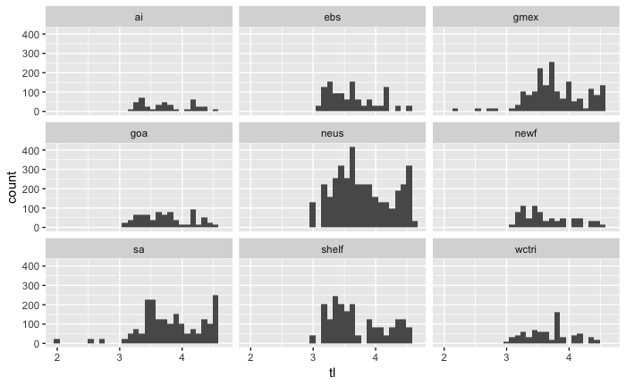

## Maximum Age for Extinction

```r
for (i in 1:length(surface_variables)){
  mod <- glmer(now_ext ~ get(surface_variables[i]) + (1|reg) + (1|year_factor), family = binomial, data = spp_master_ztemp.traits.na.age.max)
  surface_extinction_model_comparison.maxage[i,variable := surface_variables[i]]
  surface_extinction_model_comparison.maxage[i,coef := coef(summary(mod))[,"Estimate"][2]]
  surface_extinction_model_comparison.maxage[i,p_value := coef(summary(mod))[,"Pr(>|z|)"][2]]
  surface_extinction_model_comparison.maxage[i,AICc := AICc(mod)]

  print(paste(i, length(surface_variables), sep = "/"))

}
```

```
[1] "1/124"
[1] "2/124"
[1] "3/124"
[1] "4/124"
[1] "5/124"
[1] "6/124"
[1] "7/124"
[1] "8/124"
[1] "9/124"
[1] "10/124"
[1] "11/124"
[1] "12/124"
[1] "13/124"
[1] "14/124"
[1] "15/124"
```

[output cut: 109 more lines]

```r
for (i in 1:length(surface_variables)){
  mod <- glmer(now_ext ~ get(surface_variables[i]) + (1|reg) + (1|year_factor), family = binomial, data = spp_master_ztemp.traits.na.age.max)
  surface_extinction_model_comparison.maxage[i,variable := surface_variables[i]]
  surface_extinction_model_comparison.maxage[i,coef := coef(summary(mod))[,"Estimate"][2]]
  surface_extinction_model_comparison.maxage[i,p_value := coef(summary(mod))[,"Pr(>|z|)"][2]]
  surface_extinction_model_comparison.maxage[i,AICc := AICc(mod)]

  print(paste(i, length(surface_variables), sep = "/"))

}
```

```
[1] "1/124"
[1] "2/124"
[1] "3/124"
[1] "4/124"
[1] "5/124"
[1] "6/124"
[1] "7/124"
[1] "8/124"
[1] "9/124"
[1] "10/124"
[1] "11/124"
[1] "12/124"
[1] "13/124"
[1] "14/124"
[1] "15/124"
```

[output cut: 109 more lines]

```r
#looping through all possible colonization variables with single BOTTOM variables
bottom_variables <- colnames(spp_master_ztemp.traits.na.age.max[,169:292]) #same as above
bottom_extinction_model_comparison.maxage <- as.data.table(matrix(nrow = length(bottom_variables)))
bottom_extinction_model_comparison.maxage[, variable:=as.factor(V1)][, coef:=as.numeric(V1)][, p_value:=as.numeric(V1)][, AICc:=as.numeric(V1)]
bottom_extinction_model_comparison.maxage[, V1 := NULL]
for (i in 1:length(bottom_variables)){
  mod <- glmer(now_ext ~ get(bottom_variables[i]) + (1|reg) + (1|year_factor), family = binomial, data = spp_master_ztemp.traits.na.age.max)
  bottom_extinction_model_comparison.maxage[i,variable := bottom_variables[i]]
  bottom_extinction_model_comparison.maxage[i,coef := coef(summary(mod))[,"Estimate"][2]]
  bottom_extinction_model_comparison.maxage[i,p_value := coef(summary(mod))[,"Pr(>|z|)"][2]]
  bottom_extinction_model_comparison.maxage[i,AICc := AICc(mod)]

  print(paste(i, length(bottom_variables), sep = "/"))

}
```

```
[1] "1/124"
[1] "2/124"
[1] "3/124"
[1] "4/124"
[1] "5/124"
[1] "6/124"
[1] "7/124"
[1] "8/124"
[1] "9/124"
[1] "10/124"
[1] "11/124"
[1] "12/124"
[1] "13/124"
[1] "14/124"
[1] "15/124"
```

[output cut: 109 more lines]

```r
#merge surface and bottom for extinction
extinction_model_comparisons.maxage <- rbind(bottom_extinction_model_comparison.maxage, surface_extinction_model_comparison.maxage)
#lowest AICc
head(extinction_model_comparisons.maxage[order(AICc)], 30)
```

| variable | coef | p_value | AICc |
| --- | --- | --- | --- |
| min_sst_temp_change_lag2 | -0.14436022 | 0.003038827 | 3930.580 |
| seas_sbt_temp_change_lag9 | 0.12993554 | 0.005210505 | 3931.628 |
| seas_sbt_temp_lag9 | 0.10972665 | 0.013229764 | 3933.519 |
| mean_sst_temp_change_lag2 | -0.23711036 | 0.019588348 | 3933.795 |
| max_sbt_temp_change_abs | 0.15427483 | 0.017742274 | 3933.821 |
| min_sst_temp_change_abs_lag6 | 0.16578612 | 0.020123707 | 3934.268 |
| min_sbt_temp_change_abs_lag5 | -0.23173199 | 0.036076360 | 3934.596 |
| seas_sbt_temp_change_abs | 0.12245319 | 0.032188793 | 3934.761 |
| max_sbt_temp_change_lag9 | 0.11439746 | 0.035588475 | 3934.905 |
| mean_sbt_temp_change_lag2 | -0.15499342 | 0.036821976 | 3934.981 |

[output cut: 20 more lines]

Are similar models coming out on top for extinction by including maximum age?

| variable | coefficient | p | AICc | rank above | coef above |
| --- | --- | --- | --- | --- | --- |
| 1 | min_sst_temp_change_lag2 | -0.14436022 | 0.003038827 | 3930.580 | 2 |
| 2 | seas_sbt_temp_change_lag9 | 0.12993554 | 0.005210505 | 3931.628 | not in top 15 |
| 3 | seas_sbt_temp_lag9 | 0.10972665 | 0.013229764 | 3933.519 | 6 |
| 4 | max_sbt_temp_change_abs | 0.15427483 | 0.017742274 | 3933.821 | not in top 15 |
| 5 | min_sst_temp_change_abs_lag6 | 0.16578612 | 0.020123707 | 3934.268 | not in top 15 |
| 6 | min_sbt_temp_change_abs_lag5 | -0.23173199 | 0.036076360 | 3934.596 | not in top 15 |
| 7 | seas_sbt_temp_change_abs | 0.12245319 | 0.032188793 | 3934.761 | 4 |
| 9 | max_sbt_temp_change_lag9 | 0.11439746 | 0.035588475 | 3934.905 | not in top 15 |
| 10 | seas_sst_temp | -0.09460166 | 0.050126076 | 3935.655 | not in top 15 |
| 11 | min_sst_temp_change_abs_lag5 | -0.15868171 | 0.063866384 | 3935.761 | not in top 15 |
| 12 | seas_sst_temp_lag2 | 0.07970154 | 0.044236722 | 3935.820 | 12 |
| 13 | seas_sst_temp_change_abs_lag5 | -0.11465158 | 0.071676787 | 3935.918 | not in top 15 |
| 14 | seas_sst_temp_change_lag2 | 0.06818593 | 0.069610050 | 3936.028 | 7 |
| 15 | seas_sst_temp_change | -0.07118644 | 0.077429810 | 3936.153 | not in top 15 |

Of top 15 models, they only share 6… this is a problem? Seems like *min_sst_temp_change_lag2* is best to continue with?

Now we will check to see if including maximum age improves best extinction models.

```r
AICc(mod.e.agemax.0)
```

```
[1] 3930.58
```

```r
mod.e.agemax.1 <- glmer(now_ext ~ min_sst_temp_change_lag2 + age.max + (1|reg) + (1|year_factor), family = binomial, data = spp_master_ztemp.traits.na.age.max)
summary(mod.e.agemax.1)
```

```
Generalized linear mixed model fit by maximum likelihood (Laplace Approximation) ['glmerMod']
 Family: binomial  ( logit )
Formula: now_ext ~ min_sst_temp_change_lag2 + age.max + (1 | reg) + (1 |      year_factor)
   Data: spp_master_ztemp.traits.na.age.max

     AIC      BIC   logLik deviance df.resid
  3889.4   3926.6  -1939.7   3879.4    12589

Scaled residuals:
    Min      1Q  Median      3Q     Max
-0.4483 -0.2242 -0.1647 -0.1291 18.9541

Random effects:
 Groups      Name        Variance Std.Dev.
 year_factor (Intercept) 0.1325   0.3640
 reg         (Intercept) 0.3266   0.5715
Number of obs: 12594, groups:  year_factor, 45; reg, 9

Fixed effects:
                          Estimate Std. Error z value Pr(>|z|)
(Intercept)              -3.330222   0.228016 -14.605  < 2e-16 ***
min_sst_temp_change_lag2 -0.144548   0.048814  -2.961  0.00306 **
age.max                  -0.029182   0.004982  -5.857  4.7e-09 ***
---
Signif. codes:  0 ‘***’ 0.001 ‘**’ 0.01 ‘*’ 0.05 ‘.’ 0.1 ‘ ’ 1

Correlation of Fixed Effects:
            (Intr) m____2
mn_sst_t__2  0.035
age.max     -0.304  0.002
```

```r
AICc(mod.e.agemax.1)
```

```
[1] 3889.425
```

As maximum age increases, likelihood of going extinct decreases.

```r
summary(mod.e.agemax.2)
```

```
Generalized linear mixed model fit by maximum likelihood (Laplace Approximation) ['glmerMod']
 Family: binomial  ( logit )
Formula: now_ext ~ min_sst_temp_change_lag2 * age.max + (1 | reg) + (1 |      year_factor)
   Data: spp_master_ztemp.traits.na.age.max

     AIC      BIC   logLik deviance df.resid
  3890.1   3934.8  -1939.1   3878.1    12588

Scaled residuals:
    Min      1Q  Median      3Q     Max
-0.4566 -0.2233 -0.1645 -0.1294 18.6214

Random effects:
 Groups      Name        Variance Std.Dev.
 year_factor (Intercept) 0.1333   0.3652
 reg         (Intercept) 0.3272   0.5720
Number of obs: 12594, groups:  year_factor, 45; reg, 9

Fixed effects:
                                  Estimate Std. Error z value Pr(>|z|)
(Intercept)                      -3.317011   0.228513 -14.516  < 2e-16 ***
min_sst_temp_change_lag2         -0.080449   0.074287  -1.083    0.279
age.max                          -0.030339   0.005126  -5.918 3.25e-09 ***
min_sst_temp_change_lag2:age.max -0.005597   0.004830  -1.159    0.247
---
Signif. codes:  0 ‘***’ 0.001 ‘**’ 0.01 ‘*’ 0.05 ‘.’ 0.1 ‘ ’ 1

Correlation of Fixed Effects:
            (Intr) mn____2 age.mx
mn_sst_t__2  0.062
age.max     -0.307 -0.161
mn_ss___2:. -0.059 -0.753   0.244
```

```r
AICc(mod.e.agemax.2)
```

```
[1] 3890.142
```

```r
summary(mod.e.agemax.3)
```

```
Generalized linear mixed model fit by maximum likelihood (Laplace Approximation) ['glmerMod']
 Family: binomial  ( logit )
Formula: now_ext ~ age.max + (1 | reg) + (1 | year_factor)
   Data: spp_master_ztemp.traits.na.age.max

     AIC      BIC   logLik deviance df.resid
  3896.1   3925.8  -1944.0   3888.1    12590

Scaled residuals:
    Min      1Q  Median      3Q     Max
-0.4578 -0.2220 -0.1656 -0.1307 19.6499

Random effects:
 Groups      Name        Variance Std.Dev.
 year_factor (Intercept) 0.1293   0.3596
 reg         (Intercept) 0.3254   0.5705
Number of obs: 12594, groups:  year_factor, 45; reg, 9

Fixed effects:
             Estimate Std. Error z value Pr(>|z|)
(Intercept) -3.316654   0.227400 -14.585  < 2e-16 ***
age.max     -0.029179   0.004981  -5.858 4.68e-09 ***
---
Signif. codes:  0 ‘***’ 0.001 ‘**’ 0.01 ‘*’ 0.05 ‘.’ 0.1 ‘ ’ 1

Correlation of Fixed Effects:
        (Intr)
age.max -0.305
```

```r
AICc(mod.e.agemax.3)
```

```
[1] 3896.078
```

Comparing above options (no trait, yes trait, yes trait with interaction, only trait)

|  | df | AICc |
| --- | --- | --- |
| mod.e.agemax.0 | 4 | 3930.580 |
| mod.e.agemax.1 | 5 | 3889.425 |
| mod.e.agemax.2 | 6 | 3890.142 |
| mod.e.agemax.3 | 4 | 3896.078 |

Best model does not include interaction, but is nearly impossible to distinguish from model with interaction.

This tells us that as maximum age increases, log odds of going extinct decreases. As change in min temperature experienced between 2-3 years ago increases (positive change, towards warmer), the log odds of extinction decreases.

## Age of Maturity for Extinction

| variable | coef | p_value | AICc |
| --- | --- | --- | --- |
| min_sst_temp_change_lag2 | -0.14805497 | 0.002710857 | 3920.109 |
| seas_sbt_temp_change_lag9 | 0.12861632 | 0.006329875 | 3921.697 |
| seas_sbt_temp_lag9 | 0.11207541 | 0.011862688 | 3923.042 |
| mean_sst_temp_change_lag2 | -0.24567452 | 0.016427794 | 3923.251 |
| max_sbt_temp_change_abs | 0.15619946 | 0.016642456 | 3923.456 |
| min_sst_temp_change_abs_lag6 | 0.16612378 | 0.020897770 | 3924.076 |
| min_sbt_temp_change_abs_lag5 | -0.23921218 | 0.032703088 | 3924.162 |
| seas_sbt_temp_change_abs | 0.12215822 | 0.032750203 | 3924.536 |
| seas_sst_temp_lag2 | 0.08894160 | 0.021276070 | 3924.730 |
| mean_sbt_temp_change_lag2 | -0.15535315 | 0.037608814 | 3924.750 |

[output cut: 20 more lines]

Are similar models coming out on top for extinction by including age at maturity?

| variable | coefficient | p | AICc | rank above | coef above |
| --- | --- | --- | --- | --- | --- |
| 1 | min_sst_temp_change_lag2 | -0.14805497 | 0.002710857 | 3920.109 | 2 |
| 2 | seas_sbt_temp_change_lag9 | 0.12861632 | 0.006329875 | 3921.697 | not in top 15 |
| 3 | seas_sbt_temp_lag9 | 0.11207541 | 0.011862688 | 3923.042 | 6 |
| 4 | max_sbt_temp_change_abs | 0.15619946 | 0.016642456 | 3923.456 | not in top 15 |
| 5 | min_sst_temp_change_abs_lag6 | 0.16612378 | 0.020897770 | 3924.076 | not in top 15 |
| 6 | min_sbt_temp_change_abs_lag5 | -0.23921218 | 0.032703088 | 3924.162 | not in top 15 |
| 7 | seas_sbt_temp_change_abs | 0.12215822 | 0.032750203 | 3924.536 | 4 |
| 9 | seas_sst_temp_lag2 | 0.08894160 | 0.021276070 | 3924.730 | 12 |
| 10 | seas_sst_temp_change | -0.07914067 | 0.053147439 | 3925.275 | not in top 15 |
| 11 | max_sbt_temp_change_lag9 | 0.10522327 | 0.055746506 | 3925.392 | not in top 15 |
| 12 | min_sst_temp_change_abs_lag5 | -0.16304438 | 0.059969373 | 3925.406 | not in top 15 |
| 13 | seas_sst_temp_change_lag2 | 0.07202288 | 0.059464663 | 3925.501 | 7 |
| 14 | seas_sst_temp | -0.09394699 | 0.055661858 | 3925.636 | not in top 15 |
| 15 | min_sst_temp_change | 0.09385684 | 0.072201812 | 3925.738 | not in top 15 |

Of top 15, only 5 are shared

Now we will check to see if including age at maturity improves best extinction models.

```r
mod.e.agematurity.0 <- glmer(now_ext ~ min_sst_temp_change_lag2 + (1|reg) + (1|year_factor), family = binomial, data = spp_master_ztemp.traits.na.age.maturity)
summary(mod.e.agematurity.0)
```

```
Generalized linear mixed model fit by maximum likelihood (Laplace Approximation) ['glmerMod']
 Family: binomial  ( logit )
Formula: now_ext ~ min_sst_temp_change_lag2 + (1 | reg) + (1 | year_factor)
   Data: spp_master_ztemp.traits.na.age.maturity

     AIC      BIC   logLik deviance df.resid
  3920.1   3949.9  -1956.1   3912.1    12741

Scaled residuals:
    Min      1Q  Median      3Q     Max
-0.3644 -0.2345 -0.1644 -0.1280 11.0881

Random effects:
 Groups      Name        Variance Std.Dev.
 year_factor (Intercept) 0.1552   0.3939
 reg         (Intercept) 0.4014   0.6336
Number of obs: 12745, groups:  year_factor, 45; reg, 9

Fixed effects:
                         Estimate Std. Error z value Pr(>|z|)
(Intercept)              -3.82737    0.23729 -16.129  < 2e-16 ***
min_sst_temp_change_lag2 -0.14805    0.04937  -2.999  0.00271 **
---
Signif. codes:  0 ‘***’ 0.001 ‘**’ 0.01 ‘*’ 0.05 ‘.’ 0.1 ‘ ’ 1

Correlation of Fixed Effects:
            (Intr)
mn_sst_t__2 0.035
```

```r
AICc(mod.e.agematurity.0)
```

```
[1] 3920.109
```

```r
#max_sbt_temp_change_abs and age.maturity
mod.e.agematurity.1 <- glmer(now_ext ~ min_sst_temp_change_lag2 + age.maturity + (1|reg) + (1|year_factor), family = binomial, data = spp_master_ztemp.traits.na.age.maturity)
summary(mod.e.agematurity.1)
```

```
Generalized linear mixed model fit by maximum likelihood (Laplace Approximation) ['glmerMod']
 Family: binomial  ( logit )
Formula: now_ext ~ min_sst_temp_change_lag2 + age.maturity + (1 | reg) +      (1 | year_factor)
   Data: spp_master_ztemp.traits.na.age.maturity

     AIC      BIC   logLik deviance df.resid
  3906.3   3943.5  -1948.1   3896.3    12740

Scaled residuals:
    Min      1Q  Median      3Q     Max
-0.4073 -0.2240 -0.1642 -0.1288 10.5404

Random effects:
 Groups      Name        Variance Std.Dev.
 year_factor (Intercept) 0.1561   0.3951
 reg         (Intercept) 0.3634   0.6028
Number of obs: 12745, groups:  year_factor, 45; reg, 9

Fixed effects:
                         Estimate Std. Error z value Pr(>|z|)
(Intercept)              -3.54614    0.23907 -14.833  < 2e-16 ***
min_sst_temp_change_lag2 -0.14810    0.04939  -2.998 0.002714 **
age.maturity             -0.06855    0.01846  -3.714 0.000204 ***
---
Signif. codes:  0 ‘***’ 0.001 ‘**’ 0.01 ‘*’ 0.05 ‘.’ 0.1 ‘ ’ 1

Correlation of Fixed Effects:
            (Intr) m____2
mn_sst_t__2  0.035
age.maturty -0.298  0.001
```

```r
AICc(mod.e.agematurity.1)
```

```
[1] 3906.268
```

```r
#interaction?
mod.e.agematurity.2 <- glmer(now_ext ~ min_sst_temp_change_lag2 * age.maturity + (1|reg) + (1|year_factor), family = binomial, data = spp_master_ztemp.traits.na.age.maturity)
summary(mod.e.agematurity.2)
```

```
Generalized linear mixed model fit by maximum likelihood (Laplace Approximation) ['glmerMod']
 Family: binomial  ( logit )
Formula: now_ext ~ min_sst_temp_change_lag2 * age.maturity + (1 | reg) +      (1 | year_factor)
   Data: spp_master_ztemp.traits.na.age.maturity

     AIC      BIC   logLik deviance df.resid
  3908.2   3952.9  -1948.1   3896.2    12739

Scaled residuals:
    Min      1Q  Median      3Q     Max
-0.4086 -0.2235 -0.1642 -0.1288 10.5397

Random effects:
 Groups      Name        Variance Std.Dev.
 year_factor (Intercept) 0.1561   0.3951
 reg         (Intercept) 0.3631   0.6026
Number of obs: 12745, groups:  year_factor, 45; reg, 9

Fixed effects:
                                       Estimate Std. Error z value Pr(>|z|)
(Intercept)                           -3.548322   0.239095 -14.841  < 2e-16 ***
min_sst_temp_change_lag2              -0.162645   0.071988  -2.259 0.023862 *
age.maturity                          -0.067870   0.018578  -3.653 0.000259 ***
min_sst_temp_change_lag2:age.maturity  0.005069   0.018281   0.277 0.781563
---
Signif. codes:  0 ‘***’ 0.001 ‘**’ 0.01 ‘*’ 0.05 ‘.’ 0.1 ‘ ’ 1

Correlation of Fixed Effects:
            (Intr) mn____2 ag.mtr
mn_sst_t__2  0.045
age.maturty -0.300 -0.086
mn_ss___2:. -0.028 -0.728   0.113
```

```r
AICc(mod.e.agematurity.2)
```

```
[1] 3908.194
```

```r
#what about only age at maturity?
mod.e.agematurity.3 <- glmer(now_ext ~ age.maturity + (1|reg) + (1|year_factor), family = binomial, data = spp_master_ztemp.traits.na.age.maturity)
#what about only age at maturity?
mod.e.agematurity.3 <- glmer(now_ext ~ age.maturity + (1|reg) + (1|year_factor), family = binomial, data = spp_master_ztemp.traits.na.age.maturity)
summary(mod.e.agematurity.3)
```

```
Generalized linear mixed model fit by maximum likelihood (Laplace Approximation) ['glmerMod']
 Family: binomial  ( logit )
Formula: now_ext ~ age.maturity + (1 | reg) + (1 | year_factor)
   Data: spp_master_ztemp.traits.na.age.maturity

     AIC      BIC   logLik deviance df.resid
  3913.1   3942.9  -1952.6   3905.1    12741

Scaled residuals:
    Min      1Q  Median      3Q     Max
-0.4106 -0.2194 -0.1658 -0.1298 10.7251

Random effects:
 Groups      Name        Variance Std.Dev.
 year_factor (Intercept) 0.1499   0.3872
 reg         (Intercept) 0.3623   0.6019
Number of obs: 12745, groups:  year_factor, 45; reg, 9

Fixed effects:
             Estimate Std. Error z value Pr(>|z|)
(Intercept)  -3.53235    0.23826 -14.825  < 2e-16 ***
age.maturity -0.06853    0.01846  -3.713 0.000205 ***
---
Signif. codes:  0 ‘***’ 0.001 ‘**’ 0.01 ‘*’ 0.05 ‘.’ 0.1 ‘ ’ 1

Correlation of Fixed Effects:
            (Intr)
age.maturty -0.299
```

```r
AICc(mod.e.agematurity.3)
```

```
[1] 3913.139
```

Comparing above options (no trait, yes trait, yes trait with interaction, only trait)

```r
AICc(mod.e.agematurity.0, mod.e.agematurity.1, mod.e.agematurity.2, mod.e.agematurity.3)
```

|  | df | AICc |
| --- | --- | --- |
| mod.e.agematurity.0 | 4 | 3920.109 |
| mod.e.agematurity.1 | 5 | 3906.268 |
| mod.e.agematurity.2 | 6 | 3908.194 |
| mod.e.agematurity.3 | 4 | 3913.139 |

Best model includes both age at maturity and temp but not the interaction.

This tells us that as age at maturity increases,log odds of extinction decrease. Also, as change in minimum temperature experienced between 2-3 years ago increases (towards positive), log odds of extinction decreases.

## Trophic Level for Extinction

| variable | coef | p_value | AICc |
| --- | --- | --- | --- |
| min_sst_temp_change_lag2 | -0.12605189 | 0.008882239 | 4205.455 |
| seas_sbt_temp_change_abs | 0.13647286 | 0.014522389 | 4206.321 |
| seas_sbt_temp_change_lag9 | 0.11068561 | 0.016010438 | 4206.530 |
| seas_sbt_temp_lag9 | 0.10832214 | 0.014587647 | 4206.647 |
| min_sst_temp_change_abs_lag6 | 0.17395683 | 0.014698403 | 4206.661 |
| min_sbt_temp_change_abs_lag5 | -0.25022141 | 0.023335227 | 4206.734 |
| max_sbt_temp_change_abs | 0.15091446 | 0.018910307 | 4206.845 |
| min_sst_temp_change_abs_lag7 | 0.16683645 | 0.017394540 | 4206.863 |
| min_sst_temp_change_abs_lag5 | -0.18898669 | 0.027881516 | 4207.251 |
| mean_sst_temp_change_lag2 | -0.21201366 | 0.033301562 | 4207.670 |

[output cut: 20 more lines]

Are similar models coming out on top for extinction by including trophic level?

[output not shown]

Of top 15, only 6 are shared.

Now we will check to see if including trophic level improves best extinction models.

```r
#new base model (best model with no traits added)
mod.e.tl.0 <- glmer(now_ext ~ min_sst_temp_change_lag2 + (1|reg) + (1|year_factor), family = binomial, data = spp_master_ztemp.traits.na.tl)
summary(mod.e.tl.0)
```

```
Generalized linear mixed model fit by maximum likelihood (Laplace Approximation) ['glmerMod']
 Family: binomial  ( logit )
Formula: now_ext ~ min_sst_temp_change_lag2 + (1 | reg) + (1 | year_factor)
   Data: spp_master_ztemp.traits.na.tl

     AIC      BIC   logLik deviance df.resid
  4205.5   4235.4  -2098.7   4197.5    13292

Scaled residuals:
    Min      1Q  Median      3Q     Max
-0.3846 -0.2445 -0.1670 -0.1273 10.9412

Random effects:
 Groups      Name        Variance Std.Dev.
 year_factor (Intercept) 0.1634   0.4042
 reg         (Intercept) 0.4287   0.6548
Number of obs: 13296, groups:  year_factor, 45; reg, 9

Fixed effects:
                         Estimate Std. Error z value Pr(>|z|)
(Intercept)              -3.82192    0.24334 -15.706  < 2e-16 ***
min_sst_temp_change_lag2 -0.12605    0.04817  -2.617  0.00888 **
---
Signif. codes:  0 ‘***’ 0.001 ‘**’ 0.01 ‘*’ 0.05 ‘.’ 0.1 ‘ ’ 1

Correlation of Fixed Effects:
            (Intr)
mn_sst_t__2 0.029
```

```r
AICc(mod.e.tl.0)
```

```
[1] 4205.455
```

```r
mod.e.tl.1 <- glmer(now_ext ~ min_sst_temp_change_lag2 + tl + (1|reg) + (1|year_factor), family = binomial, data = spp_master_ztemp.traits.na.tl)
summary(mod.e.tl.1)
```

```
Generalized linear mixed model fit by maximum likelihood (Laplace Approximation) ['glmerMod']
 Family: binomial  ( logit )
Formula: now_ext ~ min_sst_temp_change_lag2 + tl + (1 | reg) + (1 | year_factor)
   Data: spp_master_ztemp.traits.na.tl

     AIC      BIC   logLik deviance df.resid
  4192.3   4229.8  -2091.1   4182.3    13291

Scaled residuals:
    Min      1Q  Median      3Q     Max
-0.4476 -0.2340 -0.1626 -0.1274 10.8775

Random effects:
 Groups      Name        Variance Std.Dev.
 year_factor (Intercept) 0.1645   0.4056
 reg         (Intercept) 0.4470   0.6686
Number of obs: 13296, groups:  year_factor, 45; reg, 9

Fixed effects:
                         Estimate Std. Error z value Pr(>|z|)
(Intercept)              -2.36179    0.44387  -5.321 1.03e-07 ***
min_sst_temp_change_lag2 -0.12635    0.04823  -2.620   0.0088 **
tl                       -0.39633    0.10089  -3.928 8.55e-05 ***
---
Signif. codes:  0 ‘***’ 0.001 ‘**’ 0.01 ‘*’ 0.05 ‘.’ 0.1 ‘ ’ 1

Correlation of Fixed Effects:
            (Intr) m____2
mn_sst_t__2  0.013
tl          -0.830  0.003
```

```r
AICc(mod.e.tl.1)
```

```
[1] 4192.295
```

```r
mod.e.tl.2 <- glmer(now_ext ~ min_sst_temp_change_lag2 * tl + (1|reg) + (1|year_factor), family = binomial, data = spp_master_ztemp.traits.na.tl)
summary(mod.e.tl.2)
```

```
Generalized linear mixed model fit by maximum likelihood (Laplace Approximation) ['glmerMod']
 Family: binomial  ( logit )
Formula: now_ext ~ min_sst_temp_change_lag2 * tl + (1 | reg) + (1 | year_factor)
   Data: spp_master_ztemp.traits.na.tl

     AIC      BIC   logLik deviance df.resid
  4194.2   4239.2  -2091.1   4182.2    13290

Scaled residuals:
    Min      1Q  Median      3Q     Max
-0.4500 -0.2340 -0.1624 -0.1276 10.8796

Random effects:
 Groups      Name        Variance Std.Dev.
 year_factor (Intercept) 0.1646   0.4057
 reg         (Intercept) 0.4470   0.6686
Number of obs: 13296, groups:  year_factor, 45; reg, 9

Fixed effects:
                            Estimate Std. Error z value Pr(>|z|)
(Intercept)                 -2.34541    0.44713  -5.246 1.56e-07 ***
min_sst_temp_change_lag2    -0.03522    0.30747  -0.115    0.909
tl                          -0.40081    0.10198  -3.930 8.49e-05 ***
min_sst_temp_change_lag2:tl -0.02460    0.08190  -0.300    0.764
---
Signif. codes:  0 ‘***’ 0.001 ‘**’ 0.01 ‘*’ 0.05 ‘.’ 0.1 ‘ ’ 1

Correlation of Fixed Effects:
            (Intr) mn____2 tl
mn_sst_t__2  0.119
tl          -0.833 -0.140
mn_sst___2: -0.119 -0.988   0.144
```

```r
AICc(mod.e.tl.2)
```

```
[1] 4194.209
```

```r
#what about only trophic level?
mod.e.tl.3 <- glmer(now_ext ~ tl + (1|reg) + (1|year_factor), family = binomial, data = spp_master_ztemp.traits.na.tl)
#what about only trophic level?
mod.e.tl.3 <- glmer(now_ext ~ tl + (1|reg) + (1|year_factor), family = binomial, data = spp_master_ztemp.traits.na.tl)
summary(mod.e.tl.3)
```

```
Generalized linear mixed model fit by maximum likelihood (Laplace Approximation) ['glmerMod']
 Family: binomial  ( logit )
Formula: now_ext ~ tl + (1 | reg) + (1 | year_factor)
   Data: spp_master_ztemp.traits.na.tl

     AIC      BIC   logLik deviance df.resid
  4197.0   4227.0  -2094.5   4189.0    13292

Scaled residuals:
    Min      1Q  Median      3Q     Max
-0.4554 -0.2310 -0.1641 -0.1285 10.9769

Random effects:
 Groups      Name        Variance Std.Dev.
 year_factor (Intercept) 0.1627   0.4033
 reg         (Intercept) 0.4474   0.6689
Number of obs: 13296, groups:  year_factor, 45; reg, 9

Fixed effects:
            Estimate Std. Error z value Pr(>|z|)
(Intercept)  -2.3529     0.4438  -5.302 1.15e-07 ***
tl           -0.3960     0.1009  -3.926 8.64e-05 ***
---
Signif. codes:  0 ‘***’ 0.001 ‘**’ 0.01 ‘*’ 0.05 ‘.’ 0.1 ‘ ’ 1

Correlation of Fixed Effects:
   (Intr)
tl -0.830
```

```r
AICc(mod.e.tl.3)
```

```
[1] 4197.014
```

Comparing above options (no trait, yes trait, yes trait with interaction, only trait)

|  | df | AICc |
| --- | --- | --- |
| mod.e.tl.0 | 4 | 4205.455 |
| mod.e.tl.1 | 5 | 4192.295 |
| mod.e.tl.2 | 6 | 4194.209 |
| mod.e.tl.3 | 4 | 4197.014 |

Best model includes both trophic level and temperature, but not an interaction.

```r
#total counts in each region
spp_master_ztemp %>%
  group_by(reg) %>%
  summarise(n())
```

| reg | n() |
| --- | --- |
| ai | 648 |
| ebs | 3410 |
| gmex | 2448 |
| goa | 1274 |
| neus | 4512 |
| newf | 1152 |
| sa | 2600 |
| shelf | 1968 |
| wctri | 920 |

```r
spp_master_ztemp %>%
  group_by(reg) %>%
  summarise(sum(col)/n()) #quite even percents, NEUS a little high at 8% events are colonizations
```

| reg | sum(col)/n() |
| --- | --- |
| ai | 0.02469136 |
| ebs | 0.03577713 |
| gmex | 0.02859477 |
| goa | 0.03453689 |
| neus | 0.08466312 |
| newf | 0.03211806 |
| sa | 0.03730769 |
| shelf | 0.03252033 |
| wctri | 0.04347826 |

```r
spp_master_ztemp %>%
  group_by(reg) %>%
  summarise(sum(col)) #NEUS and EBS both high, AI very small
```

| reg | sum(col) |
| --- | --- |
| ai | 16 |
| ebs | 122 |
| gmex | 70 |
| goa | 44 |
| neus | 382 |
| newf | 37 |
| sa | 97 |
| shelf | 64 |
| wctri | 40 |

```r
spp_master_ztemp %>%
  group_by(reg) %>%
  summarise(sum(now_ext)/n()) #again, NEUS is very high, all others similar
```

| reg | sum(now_ext)/n() |
| --- | --- |
| ai | 0.01234568 |
| ebs | 0.03548387 |
| gmex | 0.02083333 |
| goa | 0.01648352 |
| neus | 0.08133865 |
| newf | 0.01996528 |
| sa | 0.03884615 |
| shelf | 0.02997967 |
| wctri | 0.02282609 |

```r
spp_master_ztemp %>%
  group_by(reg) %>%
  summarise(sum(now_ext)) #Again, EBS, NEUS, and SA all high... why more events in these regions?
```

| reg | sum(now_ext) |
| --- | --- |
| ai | 8 |
| ebs | 121 |
| gmex | 51 |
| goa | 21 |
| neus | 367 |
| newf | 23 |
| sa | 101 |
| shelf | 59 |
| wctri | 21 |

First, let’s get some regional statistics

| reg | n | n.col | col.p | n.ext | ext.p | year.first | year.last |
| --- | --- | --- | --- | --- | --- | --- | --- |
| ai | 648 | 16 | 0.02 | 8 | 0.01 | 1983 | 2014 |
| ebs | 3410 | 122 | 0.04 | 121 | 0.04 | 1984 | 2014 |
| gmex | 2448 | 70 | 0.03 | 51 | 0.02 | 1984 | 2000 |
| goa | 1274 | 44 | 0.03 | 21 | 0.02 | 1984 | 2013 |
| neus | 4512 | 382 | 0.08 | 367 | 0.08 | 1982 | 2013 |
| newf | 1152 | 37 | 0.03 | 23 | 0.02 | 1996 | 2011 |
| sa | 2600 | 97 | 0.04 | 101 | 0.04 | 1990 | 2014 |
| shelf | 1968 | 64 | 0.03 | 59 | 0.03 | 1970 | 2010 |
| wctri | 920 | 40 | 0.04 | 21 | 0.02 | 1977 | 2004 |

Now we’ll visualize regions in a plot

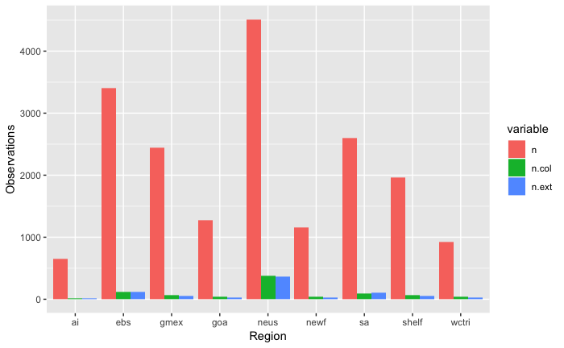